# Projet

# Modélisation par un processus auto-régressif

```r
AR <- Arima(donnee$remainder, c(4,0,0))
data <- donnee %>% mutate(res2 = AR$residuals)
```

## ACF et PACF

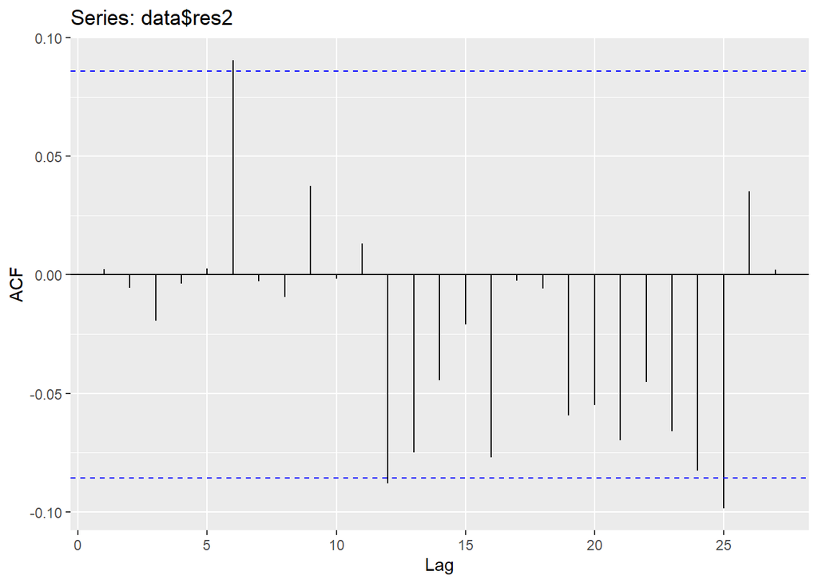

```r
ggAcf(data$res2)
```

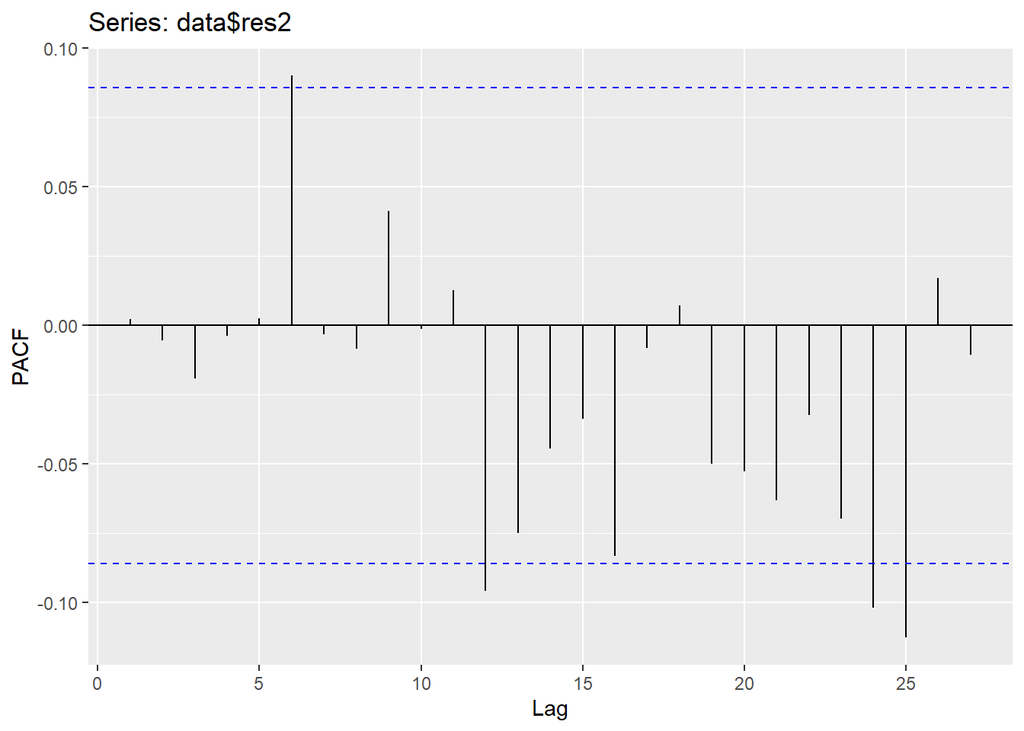

```r
ggPacf(data$res2)
```

On remarque que l’ACF et la PACF sont similaires, ce qui reflète une absence d’effet résiduel.

## Analyse des résidus

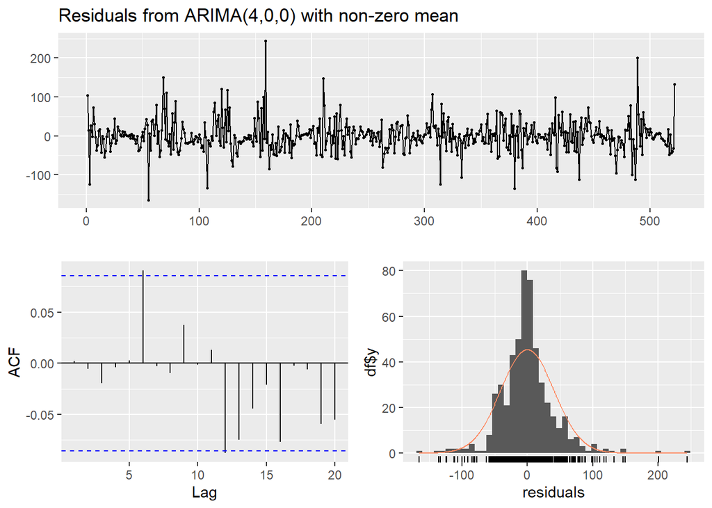

```
##
##  Ljung-Box test
##
## data:  Residuals from ARIMA(4,0,0) with non-zero mean
## Q* = 5.3789, df = 5, p-value = 0.3714
##
## Model df: 5.   Total lags used: 10
```

```r
checkresiduals(AR, lag.max=20)
```

On ne perçoit pas de struture particulière sur l’ACF, de plus la densité des résidus semblent être gaussiennes.

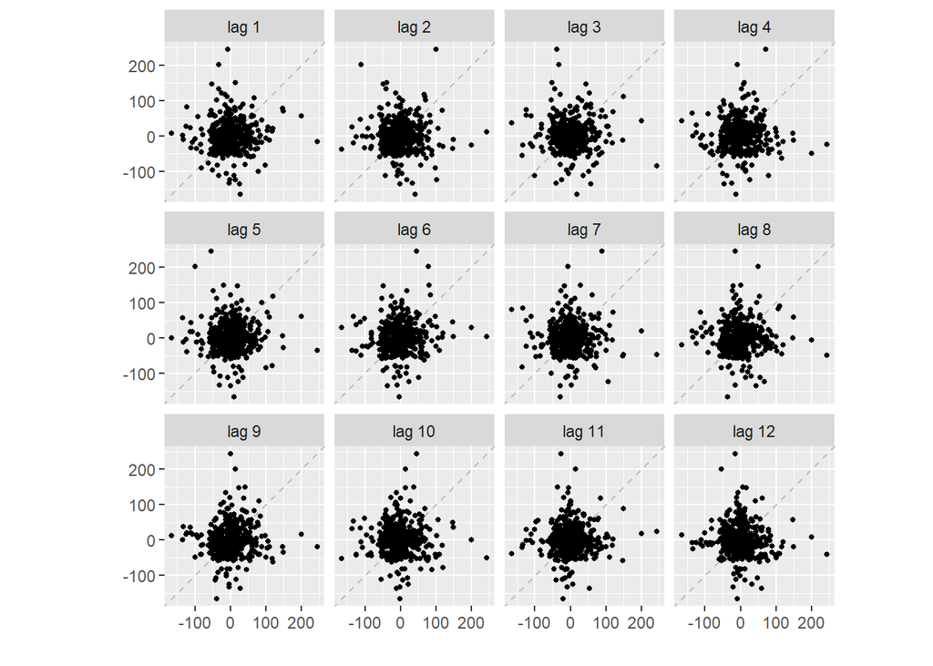

```r
gglagplot(AR$residuals, do.lines = FALSE, set.lags = 1:12, colour = FALSE)
```

Les résidus ne semblent pas corrélés, les nuages de points aux différents lags sont plutôt arrondis.

```r
Box.test(data$res2, lag = 20, type = "Box-Pierce", fitdf = 2)
```

```
##
##  Box-Pierce test
##
## data:  data$res2
## X-squared = 20.127, df = 18, p-value = 0.3257
```

```r
Box.test(data$res2, lag = 20, type = "Ljung-Box", fitdf = 2)
```

```
##
##  Box-Ljung test
##
## data:  data$res2
## X-squared = 20.708, df = 18, p-value = 0.2944
```

Les 2 test de Box-Pierce et de Box-Ljung, renvoie une p-value > 5 %, alors on ne rejette pas l’hypothèse HO selon laquelle les auto-corrélations sont nulles. Les résidus sont décoréllés.

L’estimateur de la moyenne nous indique bien que les résidus sont centrés. De plus, l’estimateur de la variance nous montre une valeur de sigma étant de 1675.

```r
mean(AR$residuals)
```

```
## [1] -0.09981575
```

```r
var(AR$residuals)
```

```
## [1] 1675.004
```

## Modèle de régression avec la décomposition de Fourrier

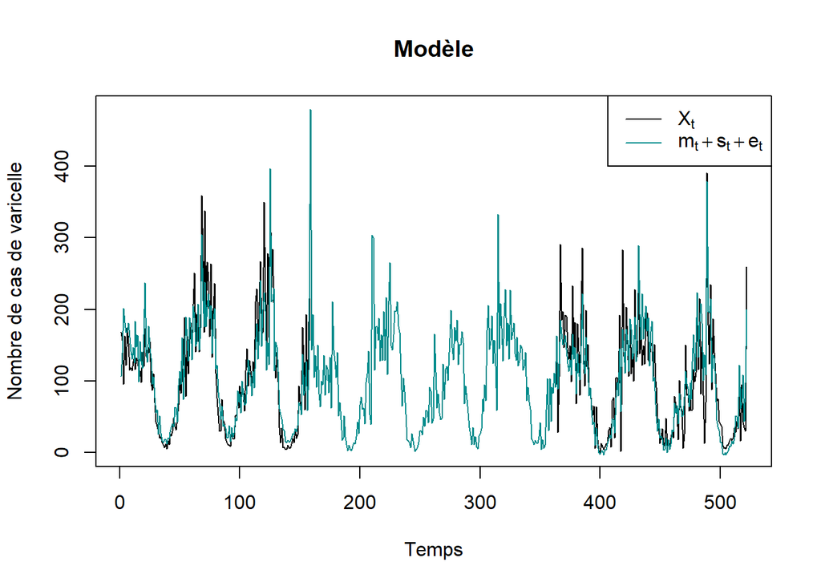

```r
t <- 1:nrow(budapest)
st <- t%o%c(rep(1:182,2))*pi/182
st[,1:182] <- cos(st[,1:182])
st[,183:364] <- sin(st[,183:364])
names(st) <- c(paste("cos",1:182),paste("sin",1:182))
df <- data.frame(st, t, x=budapest$nb)

mod <- lm(data = df, x~. )

plot(budapest$nb,xlab='Temps',ylab="Nombre de cas de varicelle",main='Modèle', type = "l")
points(mod$fitted.values, type='l',col='cyan4')
legend('topright',c(expression(X[t]),expression(m[t]+s[t]+e[t])),col=c(1,"cyan4"),lty=1)
```

# Conclusion

Nous avons un modèle additif et un modèle AR(4) sur nos résidus.

$$X_{t} = \hat m_{t}+ \hat s_{t}+ n_{t} +
BB(\sigma^{2}= 1675)$$
$$n_{t} =
\hat{a}_{1} n_{t-1}+ \hat{a}_{2} n_{t-2} + \hat{a}_{3} n_{t-3} +
\hat{a}_{4} n_{t-4}$$
un AR(4).

# Annexe

## i. Fonction *decompose* : moyennes mobiles

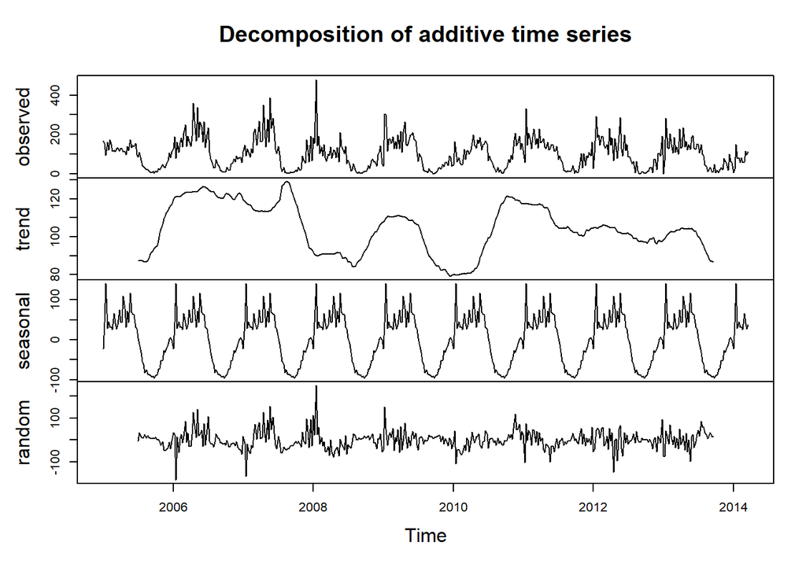

```r
budapest.ts <- ts(budapest$nb, start=c(2005,1,3),end =c(2014,12,29),  frequency=52)
budapest_dec <- decompose(budapest.ts, type = "additive")

plot(budapest_dec)
```

```r
#dev.print(device = png, file = "export2.png", width = 600)
```

## ii. Méthode des différences

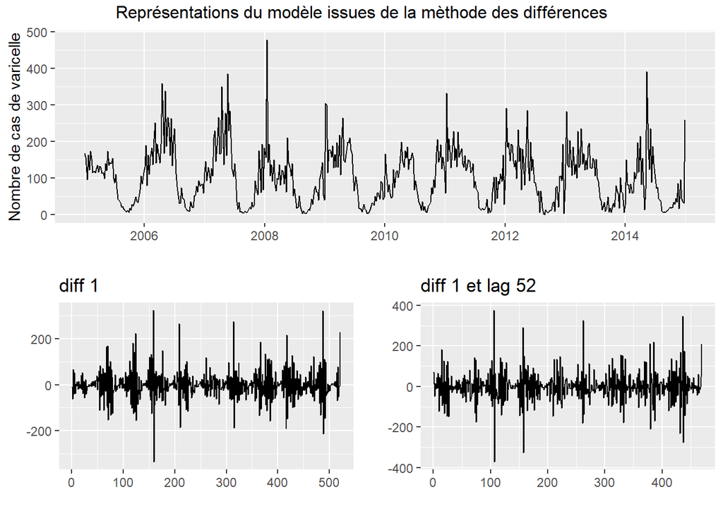

```r
T=52

xt_diff = diff(budapest$nb, differences = 1)
xt_diff_lag = diff(diff(budapest$nb, differences = 1), lag = T)

p1 <- donnee %>% ggplot() + aes(x=date, y=nb) + geom_line() +  xlab("") + ylab("Nombre de cas de varicelle")
p2 <- ggplot() + aes(x=1:521, y=xt_diff) + geom_line() + xlab("") + ylab(" ") + ggtitle("diff 1")
p3 <- ggplot() + aes(x= 1:469, y=xt_diff_lag) + geom_line() +  xlab("") + ylab(" ") + ggtitle("diff 1 et lag 52")

grid.arrange( top = "Représentations du modèle issues de la mèthode des différences", p1, p2, p3, layout_matrix = rbind(c(1,1),c(2,3)))
```

## iii. auto.arima()

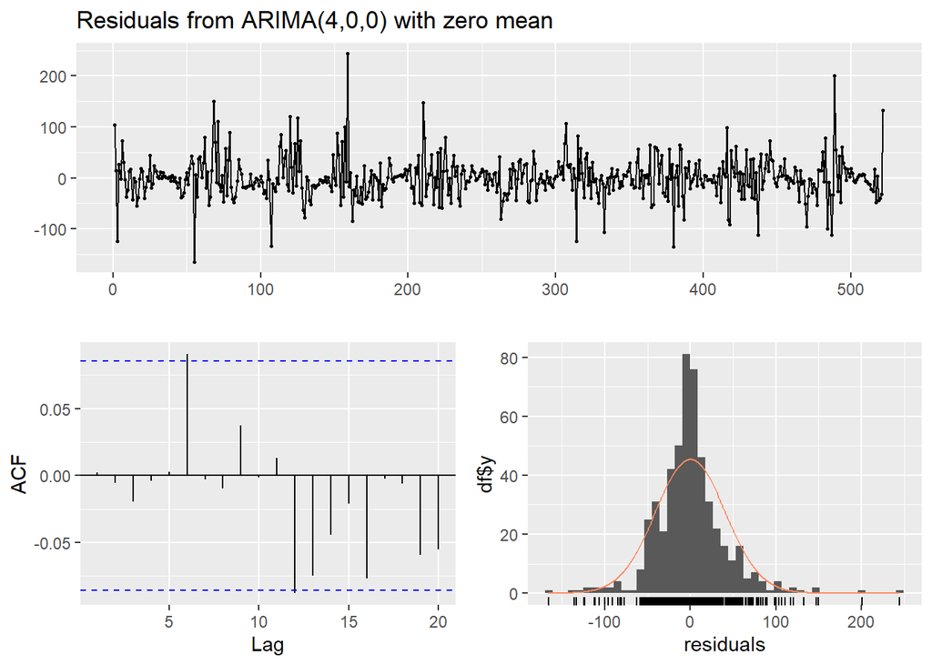

```
##
##  Ljung-Box test
##
## data:  Residuals from ARIMA(4,0,0) with zero mean
## Q* = 5.3789, df = 6, p-value = 0.4962
##
## Model df: 4.   Total lags used: 10
```

```r
arima <- auto.arima(donnee$remainder)
checkresiduals(arima, lag.max=20)
```